# IMDb Movies and TV Shows – Data Wrangling in R

Muhammad Umair

2025-09-09

# Part 1

```r
#install.packages("tidyverse")
library(dplyr)
library(tidyverse)
show <- read.csv("show.csv",stringsAsFactors = TRUE)
MaturityType <- read.csv("MaturityType.csv",stringsAsFactors = TRUE)

# rename all columns and remove spaces
names(show) <- str_replace_all(names(show), " ", "")
show$Date.Added<-as.Date(show$Date.Added,"%d/%m/%Y")
names(MaturityType) <- str_replace_all(names(MaturityType), " ", "")
summary(show)
```

```
##                                  Show.Id                     Title
##  0a00dbf9-caf1-447d-baf9-2799c2572fe6:   2   Oh My Ghost        :   3
##  38fd1f63-96c2-4f73-bdf7-286b6e111be2:   2   A Fall from Grace  :   2
##  79e9f73c-ec62-4fc7-93c5-931b1a13f1d5:   2   A Love So Beautiful:   2
##  8d50afbc-c8eb-4962-959e-54195b40db75:   2   A Trip to Jamaica  :   2
##  d4c5d002-f58c-4a54-9796-01479825cadd:   2   Alaska Is a Drag   :   2
##  00348a46-31a6-4ef7-adbb-3209d6c125eb:   1   Ali's Wedding      :   2
##  (Other)                             :4457   (Other)            :4455
##                                                                                                                                                  Description
##  A high school is rocked by an act of vandalism, but the top suspect pleads innocence and finds an ally in a filmmaker. A satirical true crime mystery.:   2
##  A newly engaged couple's romantic vacation in Jamaica turns into a mischievous adventure that tests their union in wild and unexpected ways.          :   2
##  After telling a white lie that spins out of control, the son of an Iraqi-born cleric in Melbourne becomes torn between family duty and his own heart. :   2
##  An inseparable couple struggles to stay together when betrayal threatens to tear their lives apart.                                                   :   2
##  Determined to throw off the curse of being Satan's illegitimate son, Rin enters the True Cross Academy to become an exorcist, just like his mentor.   :   2
##  Tormented by bullies, an aspiring drag star working at an Alaskan cannery becomes a skilled fighter and is tapped for competition by a boxing coach.  :   2
##  (Other)                                                                                                                                               :4456
##                    Director
##                        :1511
##  Raúl Campos, Jan Suter:  18
##  Marcus Raboy          :  15
##  Jay Karas             :  14
##  Cathy Garcia-Molina   :  12
##  Jay Chapman           :  11
##  (Other)               :2887
##                                               Genres                 Cast
##  Stand-Up Comedy                                 : 284                 : 342
##  Dramas, International Movies                    : 184   Jeff Dunham   :   7
##  Comedies, Dramas, International Movies          : 172   Jim Gaffigan  :   5
##  Documentaries                                   : 151   Bill Hicks    :   4
##  Dramas, International Movies, Romantic Movies   : 110   Dave Chappelle:   4
##  Dramas, Independent Movies, International Movies: 109   Jerry Seinfeld:   4
##  (Other)                                         :3458   (Other)       :4102
##       Production.Country  Release.Date      Rating          Duration
##  United States :1765     Min.   :1945   TV-MA  :2020   1 Season : 979
##  India         : 620     1st Qu.:2015   TV-14  :1236   2 Seasons: 287
##  United Kingdom: 243     Median :2018   TV-PG  : 388   3 Seasons: 126
##  Japan         : 217     Mean   :2016   R      : 261   97 min   :  76
##  South Korea   : 158     3rd Qu.:2019   PG-13  : 141   102 min  :  73
##  Spain         : 127     Max.   :2021   TV-G   : 112   4 Seasons:  70
##  (Other)       :1338                    (Other): 310   (Other)  :2857
##    Imdb.Score    Content.Type    Date.Added
##  7.1/10 : 183   Movie  :2905   Min.   :2008-01-01
##  7.3/10 : 165   TV Show:1563   1st Qu.:2018-08-16
##  6.6/10 : 161                  Median :2019-11-04
##  7.4/10 : 160                  Mean   :2019-07-14
##  7.0/10 : 157                  3rd Qu.:2020-09-30
##  6.4/10 : 151                  Max.   :2021-07-16
##  (Other):3491                  NA's   :949
```

```r
summary(MaturityType)
```

```
##  Maturity.Type
##  G      :1
##  NC-17  :1
##  PG     :1
##  PG-13  :1
##  R      :1
##  TV-14  :1
##  (Other):5
##                                                               Meaning
##  \tParental Guidance Suggested                                      :1
##  \tTV Show with Parental Guidance Suggested                         :1
##  Inappropriate for Ages 17 and Under.                               :1
##  Parents strongly cautioned. May be inappropriate for ages under 13.:1
##  Restricted. May be inappropriate for ages under 17                 :1
##  Suitable for General Audiences                                     :1
##  (Other)                                                            :5
```

1.2

```r
# check for duplicate rows
if (any(duplicated(show))) {
  # count the number of duplicate rows
  n_duplicates <- sum(duplicated(show))

  # display the duplicate rows
  duplicate_rows <- show[duplicated(show), ]
  print(paste0("There are ", n_duplicates, " duplicate rows:"))
  print(duplicate_rows)

  # remove the duplicate rows
  show <- show[!duplicated(show), ]
  print(paste0("After removing duplicates, the number of rows is ", nrow(show)))
} else {
  print("There are no duplicate rows.")
}
```

```
## [1] "There are 5 duplicate rows:"
##                                  Show.Id             Title
## 120 38fd1f63-96c2-4f73-bdf7-286b6e111be2 A Fall from Grace
## 177 79e9f73c-ec62-4fc7-93c5-931b1a13f1d5 A Trip to Jamaica
## 230 8d50afbc-c8eb-4962-959e-54195b40db75     Ali's Wedding
## 272 d4c5d002-f58c-4a54-9796-01479825cadd    All About Love
## 318 0a00dbf9-caf1-447d-baf9-2799c2572fe6   American Vandal
##                                                                                                                                                Description
## 120  When gentle, law-abiding Grace confesses to killing her new husband, her skeptical young lawyer sets out to uncover the truth. A film by Tyler Perry.
## 177           A newly engaged couple's romantic vacation in Jamaica turns into a mischievous adventure that tests their union in wild and unexpected ways.
## 230  After telling a white lie that spins out of control, the son of an Iraqi-born cleric in Melbourne becomes torn between family duty and his own heart.
## 272                                                    An inseparable couple struggles to stay together when betrayal threatens to tear their lives apart.
## 318 A high school is rocked by an act of vandalism, but the top suspect pleads innocence and finds an ally in a filmmaker. A satirical true crime mystery.
##             Director                                             Genres
## 120      Tyler Perry                                  Dramas, Thrillers
```

[output cut: 23 more lines]

```r
# modify the IMDB score column
show$Imdb.Score <- as.numeric(sub("/10", "", show$Imdb.Score))
```

1.3

```r
# select a production country and year of interest
Country <- "United States"
year_of_interest <- 2019

# filter the dataframe for the selected country and year
Production.Country <- show %>% filter(Production.Country == Country,
                                      Release.Date == year_of_interest,
                                      Rating == "TV-MA")
```

1.4

```r
# filter the dataframe for shows with "teen" and "high school" in the description
filtered_shows <- show %>% filter(str_detect(Description, "teen") &
                                    str_detect(Description, "high school"))

# select the desired columns and order the dataframe by release year and IMDB score
selected_shows <- filtered_shows %>%
  select(Title, Release.Date, Imdb.Score) %>%
  arrange(Release.Date, desc(Imdb.Score))

# display the top 5 rows of the resulting dataframe
head(selected_shows, 5)
```

|  | Title | Release.Date | Imdb.Score |
| --- | --- | --- | --- |
| 1 | Never Back Down | 2008 | 6.5 |
| 2 | Angel Beats! | 2010 | 7.6 |
| 3 | Inheritors | 2013 | 7.4 |
| 4 | Back to the 90s | 2015 | 6.7 |
| 5 | Degrassi: Next Class | 2017 | 6.7 |

1.5

```r
# filter the dataframe for TV shows suitable for general audiences
filtered_shows <- show %>% filter(Rating == "TV-G")

# count the number of TV shows for each production country
country_counts <- filtered_shows %>% count(Production.Country) %>%
  arrange(desc(n))

# select the top three production countries
top_countries <- head(country_counts$Production.Country, 3)

# for each top country, display the number of TV shows and average IMDB score
for (country in top_countries) {
  country_shows <- filtered_shows %>% filter(Production.Country == country)
  num_shows <- nrow(country_shows)
  avg_score <- mean(country_shows$Imdb.Score)
  print(paste0(country, ": ", num_shows, " TV shows, average IMDB score: ",
               round(avg_score, 2)))
}
```

```
## [1] "United States: 52 TV shows, average IMDB score: 6.35"
## [1] "Canada: 11 TV shows, average IMDB score: 6.06"
## [1] "Indonesia: 8 TV shows, average IMDB score: 6.79"
```

1.6

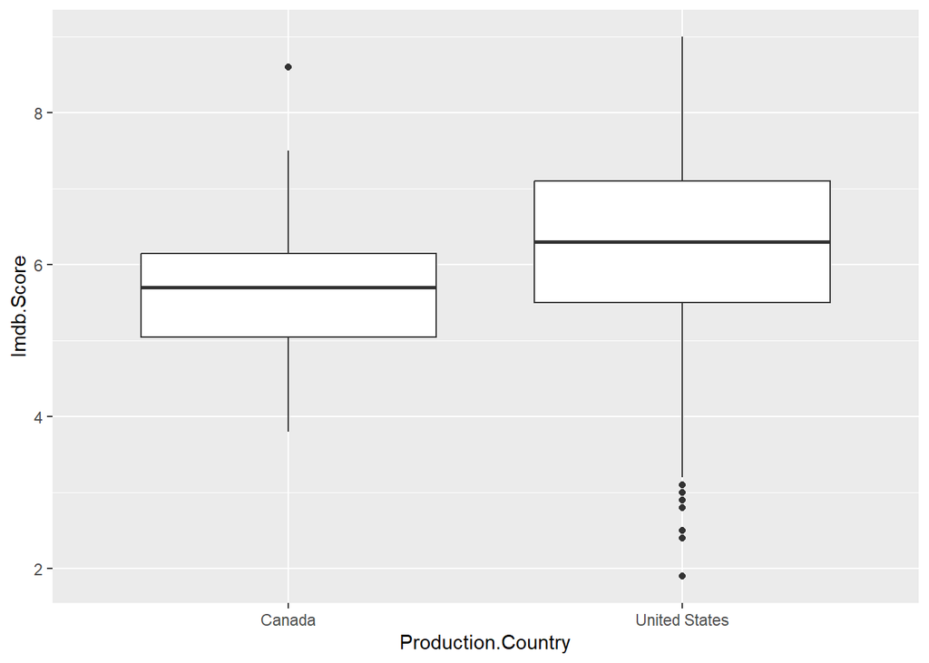

```r
# filter the dataframe for movies produced after 2010 by United States and Canada
filtered_shows <- show %>% filter(Content.Type == "Movie", Release.Date > 2010,
                                  (Production.Country == "United States" |
                                     Production.Country == "Canada"))

# draw boxplots to compare the IMDB scores
ggplot(filtered_shows, aes(x = Production.Country, y = Imdb.Score)) +
  geom_boxplot()
```

1. A ranking for children under 7 years old should take into account several factors such as age-appropriate content, positive messages, educational value, and engaging storytelling. For this purpose, we can propose a ranking based on the following two criteria:
1. Age-appropriate content: This criterion would take into account the suitability of the content for children under 7 years old, considering factors such as violence, sexual content, and language.
2. Educational value: This criterion would consider the educational value of the movie, such as the positive messages, moral values, and educational content that can stimulate the children’s learning and development.
2. Here’s an example code to find the top 5 movies based on the proposed ranking:

```r
# filter the dataframe for movies suitable for children under 7 years old
filtered_shows <- show %>% filter(Rating == "G" | Rating == "TV-Y" |
                                    Rating == "TV-Y7")

# calculate the score for each movie based on the proposed ranking criteria
scored_shows <- filtered_shows %>% mutate(Imdb.Score = (Rating == "G") +
                (Rating == "TV-Y") +  (Rating == "TV-Y7" &
                !str_detect(Description, "fear|scary|violence|blood|death")) +
                (str_detect(Description, "education|learning|knowledge|positive
                            message|moral values|value for kids")))

# select the top 5 movies with the highest score
top_movies <- scored_shows %>% select(Title, Release.Date, Imdb.Score) %>%
  arrange(desc(Imdb.Score)) %>% head(5)

# display the top 5 movies
print(top_movies)
```

```
##             Title Release.Date Imdb.Score
## 1 Growing Up Wild         2016          2
## 2     Justin Time         2012          2
## 3      Kid-E-Cats         2016          2
## 4     Llama Llama         2019          2
## 5    Luna Petunia         2017          2
```

In the above code, we first filter the `"show"` dataframe using `filter` function from `dplyr` package to select the movies suitable for children under 7 years old. We consider the movies with ratings of “G”, “TV-Y”, and “TV-Y7”, which are age-appropriate for children.

Finally, we select the top 5 movies with the highest score using `select` function, order the resulting dataframe by score in descending order using `arrange` function, and display the top 5 movies using `head` function.

3. Based on the proposed ranking criteria, the code above provides a list of top 5 movies that are suitable for children under 7 years old, taking into account their age-appropriate content and educational value. The proposed ranking criteria can help parents select movies that are not only entertaining but also beneficial for their children’s learning and development. However, it is important to note that the proposed criteria are subjective and might not capture all aspects of what makes a movie suitable for children under 7 years old. Therefore, parents should also consider their own judgment and discretion when selecting movies for their children, and take into account factors such as their children’s interests, attention span, and maturity level.

# Part B

2.1)

```r
library(readxl)
production <- read_excel("Production.xlsx",sheet = "Data")

# Rename the columns to remove the word "Year"
colnames(production) <- gsub("Year", "", colnames(production))

# Use glimpse to show the information of the data frame
glimpse(production)
```

```
## Rows: 201
## Columns: 6
## $ `Production Country / Maturity Type` <chr> "Argentina / TV-14", "Argentina /…
## $ ` 2017`                              <chr> "1 - 7.5/10", NA, "1 - 4.1/10", N…
## $ ` 2018`                              <chr> "1 - 8.2/10", NA, "8 - 6.1/10", N…
## $ ` 2019`                              <chr> NA, "1 - 7.4/10", "7 - 6.0/10", "…
## $ ` 2020`                              <chr> "5 - 6.6/10", "1 - 7.8/10", "5 - …
## $ ` 2021`                              <chr> NA, NA, NA, NA, NA, NA, NA, "1 - …
```

2.2

```r
# Pivot longer the data to transform the dataframe into the desired format
production_long <- pivot_longer(production, cols = -`Production Country / Maturity Type`,
                   names_to = "Year", values_to = "Value") %>% drop_na(Value)
```

To split the first column into two columns and give meaningful column names, you can use the `separate()` function from the `tidyr` package. Here’s how you can do it:

```r
# Separate the Production Country / Maturity Type column into two columns
production_long <- separate(production_long, `Production Country / Maturity Type`,
                            into = c("Production Country", "Maturity Type"), sep = " / ")
```

To split column `"Value"` into two columns, namely `"NumProducts"` and `"Score"`, and remove the string `"/10"` from the `"Score"` column, you can use the `separate()` function from the `tidyr` package again. Here’s how you can do it:

```r
production<- production_long %>%
  separate(col = "Value", into = c("NumProducts", "Score"), sep = " - ") %>%
  mutate(Score = as.numeric(gsub("/10", "", Score))) %>%
  filter(!is.na(Score))
head(production)
```

| Production Country | Maturity Type | Year | NumProducts | Score |
| --- | --- | --- | --- | --- |
| Argentina | TV-14 | 2017 | 1 | 7.5 |
| Argentina | TV-14 | 2018 | 1 | 8.2 |
| Argentina | TV-14 | 2020 | 5 | 6.6 |
| Argentina | TV-G | 2019 | 1 | 7.4 |
| Argentina | TV-G | 2020 | 1 | 7.8 |
| Argentina | TV-MA | 2017 | 1 | 4.1 |

This shows that the dataset production has 507 rows and 5 columns.

```r
dim(production)
```

```
## [1] 507   5
```

```r
distinct(production, "Production Country", "Year") %>%
  summarize(
    n_countries = n_distinct("Production Country"),
    n_years = n_distinct("Year")
  )
```

| n_countries | n_years |
| --- | --- |
| 1 | 1 |

2.3)

```r
mean_score<-production %>%
  group_by(`Production Country`) %>%
  summarize(mean_score = mean(Score))

production %>%
  group_by(`Production Country`) %>%
  summarize(mean_score = mean(Score)) %>%
  filter(mean_score >= 6.8 & mean_score <= 7.0)
```

| Production Country | mean_score |
| --- | --- |
| Australia | 6.894444 |
| Bangladesh | 6.900000 |
| China | 6.833333 |
| Japan | 6.957143 |
| Namibia | 7.000000 |
| New Zealand | 6.925000 |
| Sweden | 6.975000 |
| Vietnam | 6.825000 |

First, we can group the dataset by `"Production Country"` and calculate the mean of the `"Score"` column using the group_by and summarize functions

This will give us the average score for each country across all years and maturity types. We can then filter the results to only include countries with an average score between 6.8 to 7.0 using the filter function

This will give us the countries that have an average score between 6.8 to 7.0 across all years and maturity types in the dataset.

2.4)

```r
Continent<-read_excel("Production.xlsx",sheet = "Continent")

# Rename columns to "Country" and "Continent"
colnames(Continent) <- c("Country", "Continent")

# Number of countries/areas in total
total_countries <- nrow(Continent)

#Name the country coloum same as both sheet
names(production)[1]<-"Country"

countries_not_in_data <- anti_join(Continent, production, by = "Country")

# Number of countries not in the Data sheet
num_countries_not_in_data <- nrow(countries_not_in_data)
```

2.5)

To rank the Asian countries to support the decision-making of Netflix to target an Asian country to grow their market, I would suggest the following criterion:

1. Population Size: One of the key criteria could be the population size of a country. Since a larger population means a larger potential customer base, it can be a significant factor in deciding which Asian country to target. For example, India and China have the two largest populations in the world and could be good targets for Netflix.
2. Internet Penetration Rate: Another important factor could be the internet penetration rate of the country. Countries with a higher internet penetration rate could be more receptive to online streaming services like Netflix. For example, South Korea and Japan have some of the highest internet penetration rates in the world and could be good targets for Netflix.
3. Income Level: The income level of a country could also be an important factor. Countries with higher incomes are more likely to have disposable income to spend on entertainment services like Netflix. For example, Singapore and Hong Kong have high per capita income levels and could be good targets for Netflix.
4. Availability of Local Content: The availability of local content could also be an important factor in deciding which Asian country to target. Countries with a larger and more diverse range of local content could be more attractive to viewers. For example, South Korea has a thriving entertainment industry and could be a good target for Netflix due to the popularity of its dramas and music.

Overall, a combination of these criteria could be used to rank the Asian countries and help Netflix make an informed decision on which country to target to grow their market.

```r
# Merge the two dataframes
merged_data <- inner_join(production, Continent, by = "Country")

# Filter for Asian countries only
asian_data <- merged_data %>% filter(Continent == "Asia")

# Calculate the average score of TV-MA maturity type for each country
asian_scores <- asian_data %>%
  filter(`Maturity Type` == "TV-MA") %>%
  group_by(Country) %>%
  summarize(avg_score = mean(Score, na.rm = TRUE)) %>%
  ungroup()

# Rank the Asian countries based on the average score of TV-MA maturity type
ranked_data <- asian_scores %>%
  arrange(desc(avg_score))

# Print the top five Asian countries
top_five <- head(ranked_data$Country, 5)
print(top_five)
```

```
## [1] "Israel"     "Japan"      "Bangladesh" "Lebanon"    "Thailand"
```

This code loads the production data and the continent data, merges them by the `"Country"` column, filters for Asian countries only, calculates the average score of TV-MA maturity type for each country, ranks the Asian countries based on this criterion, and prints the top five Asian countries.

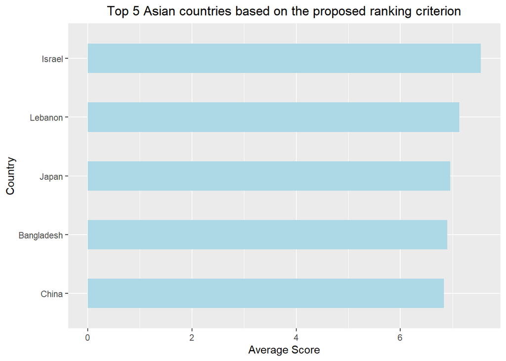

```r
country_scores <- asian_data %>%
  group_by(Country) %>%
  summarize(avg_score = mean(Score, na.rm = TRUE)) %>%
  arrange(desc(avg_score)) %>%
  top_n(5)

# create a bar chart
ggplot(country_scores, aes(x = reorder(Country, avg_score), y = avg_score)) +
  geom_col(fill = "lightblue", width = 0.5) +
  xlab("Country") +
  ylab("Average Score") +
  ggtitle("Top 5 Asian countries based on the proposed ranking criterion") +
  theme(plot.title = element_text(hjust = 0.5)) +
  coord_flip()
```